# PH364_Midterm

## Midterm Module Showcase: Astropy FITS (and sep)

The module FITS from the python library Astropy in tandem with Matplotlib is a tool that allows scientists to visualize and manipulate FITS files, which store raw image data. Astropy's FITS is useful because it can help scientists qualitatively analyze the luminosity of stellar objects and create histograms to quantitatively describe the luminosity. This module can grant insights into classifying stellar objects, such as differentiating between a single bright star or a binary star system.

While not strictly necessary, sep can be used to remove background noise from an image generated by Astropy's FITS module. This is sometimes important if an image is too distorted by the background noise to be properly analyzed.

FITS File Data Source:

- https://esahubble.org/projects/fits_liberator/eagledata/

```python
import numpy as np
import matplotlib.pyplot as plt
import sep
from astropy.io import fits
from matplotlib.colors import LogNorm
from astropy.utils.data import download_file

%matplotlib inline
```

## Step 1: Creating a Preliminary Image and Histogram

Documentation:

- https://learn.astropy.org/tutorials/FITS-images.html
- https://docs.astropy.org/en/latest/io/fits/index.html
- https://matplotlib.org/stable/api/pyplot_summary.html

I first use the function `fits.open` which allows me to open a FITS file that I have downloaded to my computer. This function accepts a string for its `name` parameter, which is the file path to my FITS file. I can then use `hdu_list.info()` to display the content for the first few lines of my FITS file.

`fits.open` will additionally let me specify if I want to use memory mapping, save a backup of the original file if I edit the file, and only read a specific amount of HDUs (Header Data Unit) if I am working with a particularly large FITS file. This is a non-exhaustive list and these parameters are all optional aside from `name`.

Defaults: `fits.open(name, mode='readonly', memmap=None, save_backup=False, cache=True, lazy_load_hdus=None, ignore_missing_simple=False, *, use_fsspec=None, fsspec_kwargs=None, decompress_in_memory=False, **kwargs)`

```python
hdu_list = fits.open('/home/xspoole/classes/ph364/502nmos.fits') # 502nmos.fits is the name of my FITS file
hdu_list.info() # display FITS file content
```

```
Filename: /home/xspoole/classes/ph364/502nmos.fits
No.    Name      Ver    Type      Cards   Dimensions   Format
  0  PRIMARY       1 PrimaryHDU     290   (1600, 1600)   float32
  1  502nmos_cvt.tab    1 TableHDU       353   1R x 49C   [D25.17, D25.17, E15.7, E15.7, E15.7, E15.7, E15.7, E15.7, E15.7, E15.7, A1, E15.7, I12, I12, D25.17, D25.17, A8, A8, I12, E15.7, E15.7, E15.7, E15.7, E15.7, E15.7, I12, I12, I12, I12, I12, I12, I12, I12, A48, E15.7, E15.7, E15.7, E15.7, E15.…
```

The information for the image is stored in the `PRIMARY` row of the FITS file. Therefore, I define the variable `image_data` as being the `PRIMARY` row by using the function `hdu_list[0].data`. This indexes the `PRIMARY` row such that it is able to be used to make a visual representation of the data.

```python
image_data = hdu_list[0].data
```

I generate a preliminary plot of my `image_data` using Matplotlib. The function `plt.imshow` creates a visual representation of a 2D array and accepts arguments for the parameters image data, the value range for the colormap, and a color for the map. I chose `cmap="magma"` because I like it, but there are plenty of other options.

Defaults: `plt.imshow(X, cmap=None, norm=None, *, aspect=None, interpolation=None, alpha=None, vmin=None, vmax=None, colorizer=None, origin=None, extent=None, interpolation_stage=None, filternorm=True, filterrad=4.0, resample=None, url=None, data=None, **kwargs)`

`plt.colorbar` adds a bar to the right side of the image which displays a gradient of colors mapped to numerical values.

[figure not shown]

```python
plt.imshow(image_data.T, cmap="magma", vmin=-10, vmax=20) # .T transposes the image_data matrix so that the image is rotated 90 degrees
plt.colorbar()
```

Next, I can generate a preliminary histogram of my data by transforming my image data from a 2D array into a 1D array using numpy's `flatten` function. The histogram describes the number of pixels at a certain value. In this case, the higher values correspond to brighter objects in the image like stars. Because this image has a lot of background noise, the histogram doesn't have a lot of variance between more and less luminous objects, such as the star in the middle of the image.

```
(0.0, 11000.0)
```

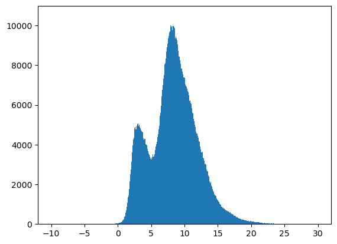

```python
bins = np.linspace(-10, 30, 1000)
histogram = plt.hist(image_data.flatten(), bins)
plt.ylim(0,11000)
```

## Step 2: Separating Background Noise

Documentation:

- https://sep.readthedocs.io/en/v1.1.x/tutorial.html
- https://sep.readthedocs.io/en/stable/

I use the package `sep` to generate an image and histogram without background noise. `sep.Background` is a function that estimates the background noise in the FITS file. The variable `bkg` can then be subtracted from my original data to create an image and histogram without the noise. I can change the dimensions of the bins and filter to better fit my data. The smaller the bins, the more contrasted `bkg` will become. The filter is used to smooth out harsh transitions in the image.

Defaults: `sep.Background(data, mask=None, maskthresh=0.0, bw=64, bh=64, fw=3, fh=3, fthresh=0.0)`

```python
data = image_data.astype(image_data.dtype.newbyteorder('=')) # changing byte order to match my computer's architecture

bkg = sep.Background(data, bw=256, bh=256, fw=5, fh=7)
```

To visualize the background data that I am subtracting from my original data, I can use the function `bkg.back` to transform the background into a 2D array. Then, I plot it to see a median estimate of the background light or "glow" per pixel.

I can use this visualization to help me to adjust my bin dimensions. When the bin dimension is too low, more of the structure of the nebula is visible in the `bkg.back` plot, meaning that data is subtracted from the original image. I adjusted my bin dimensions to be larger to avoid this.

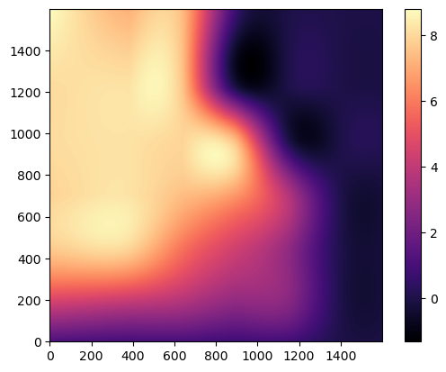

```python
bkg_image = bkg.back() # evaluate estimated background "glow" as a 2D array

# show plot of estimated median "glow"
rotated_img = np.rot90(bkg_image, k=1)
plt.imshow(rotated_img, interpolation='nearest', cmap='magma', origin='lower')
plt.colorbar()
```

The function `bkg.rms` is similar to `bkg.back` but instead is an estimation of the background noise's standard deviation. The "rms" in the function stands for "root mean square". I can also create a visualization of this.

This visualization allows me to adjust my filter dimensions. When the edges of the blocks of color are very sharp in the `bkg.rms` plot, that means my filter is too low. I can adjust my filter such that the edges of the blocks of color are sufficiently blended, but not too blended.

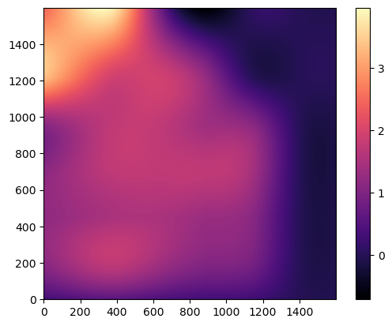

```python
bkg_rms = bkg.rms() # evaluate estimated background noise as a 2D array

# show plot of the estimated noise
rotated_img = np.rot90(bkg_rms, k=1)
plt.imshow(rotated_img, interpolation='nearest', cmap='magma', origin='lower')
plt.colorbar()
```

## Step 3: Creating the Final Image and Histogram

I create a new variable `data_sub` which subtracts the background noise from my original image. Then, using `plt.imshow`, I generate my new image and histogram. If the image appears too grainy or the colors seem too flat, then I can adjust the bin and filter dimensions until the image appears clear. If a scientist is intending to classify stellar objects, then it is important to ensure that bright objects are easily differentiable.

[figure not shown]

```python
data_sub = data - bkg # subtract the background noise from the original image

plt.imshow(data_sub.T, cmap="magma", vmin=-14, vmax=20)
plt.colorbar()
```

```
(0.0, 60000.0)
```

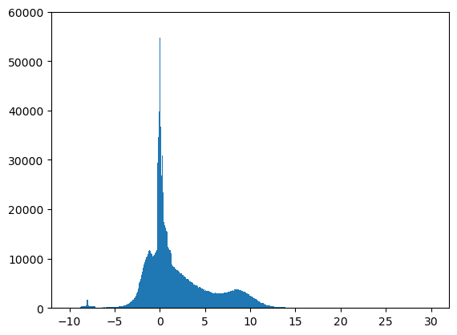

```python
bins = np.linspace(-10, 30, 1000)
histogram = plt.hist(data_sub.flatten(), bins)
plt.ylim(0,60000)
```

Now that I have generated my new image, Astropy's FITS module will allow me to create a new FITS file with the adjusted data. I specify what I want the new FITS file to be called in the variable `outfile` and then use the function `fits.PrimaryHDU`. This function constructs a new HDU to go in the `PRIMARY` row of the FITS file, which is where the image data is stored. Finally, I use the function `writeto` to create my new file and specify `overwrite=True` so that if I want to adjust my image, `outfile` will be updated without creating a new file.

In the `fits.PrimaryHDU` function, I must include an argument for the data parameter, but the other parameters are optional. If I choose to, I can specify if I want to scale my image data with `BSCALE/BZERO` values. I can also include a header for my data.

Defaults: `fits.PrimaryHDU(data=None, header=None, do_not_scale_image_data=False, ignore_blank=False, uint=True, scale_back=None)`

```python
outfile = "adjusted_pillars_of_creation.fits"

hdu = fits.PrimaryHDU(data_sub)
hdu.writeto(outfile, overwrite=True)
```